# 넥슨 api 활용 데이터 분석

- 직업간 무릉도장 모험가 직업 상위 100명의 층수와 타임어택 데이터 분석
- 기준일 2023-12-22
- 특정직업은 100개의 카운트가 되지 않았음

## import

```python
import requests
import pandas as pd
from urllib.parse import urlparse
import matplotlib.pyplot as plt
```

```python
key1="test_5aec3c1d647d828fc003c519cfdfb186136a454f3b157fe1de4871fa3b1cfd36054e93d4bc30eea6a5bdcb353aee8375" # 보안필요
```

## read data

- 파일 읽기와 필요 데이터 추출 및 데이터프레임으로 생성

```python
class Dojang():
    def read(self,key,url,job):
        headers = { "x-nxopen-api-key":
                   key}
        rqt = requests.get(url, headers = headers)
        rqt.json()
        row = rqt.json()
        feature1 = [row['ranking'][i]['dojang_floor'] for i in range(len(row['ranking']))][0:100]
        feature2 = [row['ranking'][i]['dojang_time_record'] for i in range(len(row['ranking']))][0:100]
        name = [job]*len(row['ranking'][0:100])
        df = pd.DataFrame({'floor':feature1,'time':feature2,'job':name})
        return df
        #return lst
```

`-` 각 직업의 무릉 api

```python
# 모험가
duarblade_url='https://open.api.nexon.com/maplestory/v1/ranking/dojang?date=2023-12-22&difficulty=1&class=%EB%8F%84%EC%A0%81-%EB%93%80%EC%96%BC%EB%B8%94%EB%A0%88%EC%9D%B4%EB%8D%94'
hero_url = 'https://open.api.nexon.com/maplestory/v1/ranking/dojang?date=2023-12-22&difficulty=1&class=%EC%A0%84%EC%82%AC-%ED%9E%88%EC%96%B4%EB%A1%9C'
darknight = 'https://open.api.nexon.com/maplestory/v1/ranking/dojang?date=2023-12-22&difficulty=1&class=%EC%A0%84%EC%82%AC-%EB%8B%A4%ED%81%AC%EB%82%98%EC%9D%B4%ED%8A%B8'
paladin ='https://open.api.nexon.com/maplestory/v1/ranking/dojang?date=2023-12-22&difficulty=1&class=%EC%A0%84%EC%82%AC-%ED%8C%94%EB%9D%BC%EB%94%98'
mage_fire = 'https://open.api.nexon.com/maplestory/v1/ranking/dojang?date=2023-12-22&difficulty=1&class=%EB%A7%88%EB%B2%95%EC%82%AC-%EC%95%84%ED%81%AC%EB%A9%94%EC%9D%B4%EC%A7%80%28%EB%B6%88%2C%EB%8F%85%29'
mage_ice ='https://open.api.nexon.com/maplestory/v1/ranking/dojang?date=2023-12-22&difficulty=1&class=%EB%A7%88%EB%B2%95%EC%82%AC-%EC%95%84%ED%81%AC%EB%A9%94%EC%9D%B4%EC%A7%80%28%EC%8D%AC%2C%EC%BD%9C%29'
bishop ='https://open.api.nexon.com/maplestory/v1/ranking/dojang?date=2023-12-22&difficulty=1&class=%EB%A7%88%EB%B2%95%EC%82%AC-%EB%B9%84%EC%88%8D'
singung ='https://open.api.nexon.com/maplestory/v1/ranking/dojang?date=2023-12-22&difficulty=1&class=%EA%B6%81%EC%88%98-%EC%8B%A0%EA%B6%81'
bowmaster ='https://open.api.nexon.com/maplestory/v1/ranking/dojang?date=2023-12-22&difficulty=1&class=%EA%B6%81%EC%88%98-%EB%B3%B4%EC%9A%B0%EB%A7%88%EC%8A%A4%ED%84%B0'
pathfinder ='https://open.api.nexon.com/maplestory/v1/ranking/dojang?date=2023-12-22&difficulty=1&class=%EA%B6%81%EC%88%98-%ED%8C%A8%EC%8A%A4%ED%8C%8C%EC%9D%B8%EB%8D%94'
biper = 'https://open.api.nexon.com/maplestory/v1/ranking/dojang?date=2023-12-22&difficulty=1&class=%ED%95%B4%EC%A0%81-%EB%B0%94%EC%9D%B4%ED%8D%BC'
captin ='https://open.api.nexon.com/maplestory/v1/ranking/dojang?date=2023-12-22&difficulty=1&class=%ED%95%B4%EC%A0%81-%EC%BA%A1%ED%8B%B4'
canonmaster = 'https://open.api.nexon.com/maplestory/v1/ranking/dojang?date=2023-12-22&difficulty=1&class=%ED%95%B4%EC%A0%81-%EC%BA%90%EB%85%BC%EB%A7%88%EC%8A%A4%ED%84%B0'
naro = 'https://open.api.nexon.com/maplestory/v1/ranking/dojang?date=2023-12-22&difficulty=1&class=%EB%8F%84%EC%A0%81-%EB%82%98%EC%9D%B4%ED%8A%B8%EB%A1%9C%EB%93%9C'
shadore ='https://open.api.nexon.com/maplestory/v1/ranking/dojang?date=2023-12-22&difficulty=1&class=%EB%8F%84%EC%A0%81-%EC%84%80%EB%8F%84%EC%96%B4'
# 시그너스
soulmaster = 'https://open.api.nexon.com/maplestory/v1/ranking/dojang?date=2023-12-22&difficulty=1&class=%EA%B8%B0%EC%82%AC%EB%8B%A8-%EC%86%8C%EC%9A%B8%EB%A7%88%EC%8A%A4%ED%84%B0'
flamewizard = 'https://open.api.nexon.com/maplestory/v1/ranking/dojang?date=2023-12-22&difficulty=1&class=%EA%B8%B0%EC%82%AC%EB%8B%A8-%ED%94%8C%EB%A0%88%EC%9E%84%EC%9C%84%EC%9E%90%EB%93%9C'
windbreaker = 'https://open.api.nexon.com/maplestory/v1/ranking/dojang?date=2023-12-22&difficulty=1&class=%EA%B8%B0%EC%82%AC%EB%8B%A8-%EC%9C%88%EB%93%9C%EB%B8%8C%EB%A0%88%EC%9D%B4%EC%BB%A4'
nightwalker = 'https://open.api.nexon.com/maplestory/v1/ranking/dojang?date=2023-12-22&difficulty=1&class=%EA%B8%B0%EC%82%AC%EB%8B%A8-%EB%82%98%EC%9D%B4%ED%8A%B8%EC%9B%8C%EC%BB%A4'
striker = 'https://open.api.nexon.com/maplestory/v1/ranking/dojang?date=2023-12-22&difficulty=1&class=%EA%B8%B0%EC%82%AC%EB%8B%A8-%EC%8A%A4%ED%8A%B8%EB%9D%BC%EC%9D%B4%EC%BB%A4'
mihaie ='https://open.api.nexon.com/maplestory/v1/ranking/dojang?date=2023-12-22&difficulty=1&class=%EA%B8%B0%EC%82%AC%EB%8B%A8-%EB%AF%B8%ED%95%98%EC%9D%BC'
#영웅
aran = 'https://open.api.nexon.com/maplestory/v1/ranking/dojang?date=2023-12-22&difficulty=1&class=%EC%95%84%EB%9E%80-%EC%A0%84%EC%B2%B4%20%EC%A0%84%EC%A7%81'
evan = 'https://open.api.nexon.com/maplestory/v1/ranking/dojang?date=2023-12-22&difficulty=1&class=%EC%97%90%EB%B0%98-%EC%A0%84%EC%B2%B4%20%EC%A0%84%EC%A7%81'
pantom = 'https://open.api.nexon.com/maplestory/v1/ranking/dojang?date=2023-12-22&difficulty=1&class=%ED%8C%AC%ED%85%80-%EC%A0%84%EC%B2%B4%20%EC%A0%84%EC%A7%81'
meresedes ='https://open.api.nexon.com/maplestory/v1/ranking/dojang?date=2023-12-22&difficulty=1&class=%EB%A9%94%EB%A5%B4%EC%84%B8%EB%8D%B0%EC%8A%A4-%EC%A0%84%EC%B2%B4%20%EC%A0%84%EC%A7%81'
luminus ='https://open.api.nexon.com/maplestory/v1/ranking/dojang?date=2023-12-22&difficulty=1&class=%EB%A3%A8%EB%AF%B8%EB%84%88%EC%8A%A4-%EC%A0%84%EC%B2%B4%20%EC%A0%84%EC%A7%81'
eunwal ='https://open.api.nexon.com/maplestory/v1/ranking/dojang?date=2023-12-22&difficulty=1&class=%EC%9D%80%EC%9B%94-%EC%A0%84%EC%B2%B4%20%EC%A0%84%EC%A7%81'


#레지스탕스
bathlemage ='https://open.api.nexon.com/maplestory/v1/ranking/dojang?date=2023-12-22&difficulty=1&class=%EB%A0%88%EC%A7%80%EC%8A%A4%ED%83%95%EC%8A%A4-%EB%B0%B0%ED%8B%80%EB%A9%94%EC%9D%B4%EC%A7%80'
wildhunter ='https://open.api.nexon.com/maplestory/v1/ranking/dojang?date=2023-12-22&difficulty=1&class=%EB%A0%88%EC%A7%80%EC%8A%A4%ED%83%95%EC%8A%A4-%EC%99%80%EC%9D%BC%EB%93%9C%ED%97%8C%ED%84%B0'
mecahinc ='https://open.api.nexon.com/maplestory/v1/ranking/dojang?date=2023-12-22&difficulty=1&class=%EB%A0%88%EC%A7%80%EC%8A%A4%ED%83%95%EC%8A%A4-%EB%A9%94%EC%B9%B4%EB%8B%89'
demonslayer ='https://open.api.nexon.com/maplestory/v1/ranking/dojang?date=2023-12-22&difficulty=1&class=%EB%A0%88%EC%A7%80%EC%8A%A4%ED%83%95%EC%8A%A4-%EB%8D%B0%EB%AA%AC%EC%8A%AC%EB%A0%88%EC%9D%B4%EC%96%B4'
demonavanger='https://open.api.nexon.com/maplestory/v1/ranking/dojang?date=2023-12-22&difficulty=1&class=%EB%A0%88%EC%A7%80%EC%8A%A4%ED%83%95%EC%8A%A4-%EB%8D%B0%EB%AA%AC%EC%96%B4%EB%B2%A4%EC%A0%B8'
xenon ='https://open.api.nexon.com/maplestory/v1/ranking/dojang?date=2023-12-22&difficulty=1&class=%EB%A0%88%EC%A7%80%EC%8A%A4%ED%83%95%EC%8A%A4-%EC%A0%9C%EB%85%BC'
blaster ='https://open.api.nexon.com/maplestory/v1/ranking/dojang?date=2023-12-22&difficulty=1&class=%EB%A0%88%EC%A7%80%EC%8A%A4%ED%83%95%EC%8A%A4-%EB%B8%94%EB%9E%98%EC%8A%A4%ED%84%B0'
#노바
kizer ='https://open.api.nexon.com/maplestory/v1/ranking/dojang?date=2023-12-22&difficulty=1&class=%EC%B9%B4%EC%9D%B4%EC%A0%80-%EC%A0%84%EC%B2%B4%20%EC%A0%84%EC%A7%81'
angelicbuster ='https://open.api.nexon.com/maplestory/v1/ranking/dojang?date=2023-12-22&difficulty=1&class=%EC%97%94%EC%A0%A4%EB%A6%AD%EB%B2%84%EC%8A%A4%ED%84%B0-%EC%A0%84%EC%B2%B4%20%EC%A0%84%EC%A7%81'
kadena ='https://open.api.nexon.com/maplestory/v1/ranking/dojang?date=2023-12-22&difficulty=1&class=%EC%B9%B4%EB%8D%B0%EB%82%98-%EC%A0%84%EC%B2%B4%20%EC%A0%84%EC%A7%81'
kain ='https://open.api.nexon.com/maplestory/v1/ranking/dojang?date=2023-12-22&difficulty=1&class=%EC%B9%B4%EC%9D%B8-%EC%A0%84%EC%B2%B4%20%EC%A0%84%EC%A7%81'
#레프
adel ='https://open.api.nexon.com/maplestory/v1/ranking/dojang?date=2023-12-22&difficulty=1&class=%EC%95%84%EB%8D%B8-%EC%A0%84%EC%B2%B4%20%EC%A0%84%EC%A7%81'
ark ='https://open.api.nexon.com/maplestory/v1/ranking/dojang?date=2023-12-22&difficulty=1&class=%EC%95%84%ED%81%AC-%EC%A0%84%EC%B2%B4%20%EC%A0%84%EC%A7%81'
liyum ='https://open.api.nexon.com/maplestory/v1/ranking/dojang?date=2023-12-22&difficulty=1&class=%EC%9D%BC%EB%A6%AC%EC%9B%80-%EC%A0%84%EC%B2%B4%20%EC%A0%84%EC%A7%81'
kaly ='https://open.api.nexon.com/maplestory/v1/ranking/dojang?date=2023-12-22&difficulty=1&class=%EC%B9%BC%EB%A6%AC-%EC%A0%84%EC%B2%B4%20%EC%A0%84%EC%A7%81'
#나머지
zero ='https://open.api.nexon.com/maplestory/v1/ranking/dojang?date=2023-12-22&difficulty=1&class=%EC%B4%88%EC%9B%94%EC%9E%90-%EC%A0%9C%EB%A1%9C'
kinecis ='https://open.api.nexon.com/maplestory/v1/ranking/dojang?date=2023-12-22&difficulty=1&class=%ED%94%84%EB%A0%8C%EC%A6%88%20%EC%9B%94%EB%93%9C-%ED%82%A4%EB%84%A4%EC%8B%9C%EC%8A%A4'
hoyoung ='https://open.api.nexon.com/maplestory/v1/ranking/dojang?date=2023-12-22&difficulty=1&class=%ED%98%B8%EC%98%81-%EC%A0%84%EC%B2%B4%20%EC%A0%84%EC%A7%81'
rara ='https://open.api.nexon.com/maplestory/v1/ranking/dojang?date=2023-12-22&difficulty=1&class=%EB%9D%BC%EB%9D%BC-%EC%A0%84%EC%B2%B4%20%EC%A0%84%EC%A7%81'
```

```python
test1= Dojang()
dualbalde=test1.read(key1,duarblade_url,'듀얼블레이드')
hero=test1.read(key1,hero_url,'히어로')
darknight=test1.read(key1,darknight,'다크나이트')
paladin=test1.read(key1,paladin,'팔라딘')
mage_fire=test1.read(key1,mage_fire,'불독')
mage_ice=test1.read(key1,mage_ice,'썬콜')
bishop=test1.read(key1,bishop,'비숍')
singung=test1.read(key1,singung,'신궁')
bowmaster=test1.read(key1,bowmaster,'보우마스터')
pathfinder=test1.read(key1,pathfinder,'패스파인더')
biper=test1.read(key1,biper,'바이퍼')
captin=test1.read(key1,captin,'캡틴')
canonmaster=test1.read(key1,canonmaster,'캐논마스터')
naro =test1.read(key1,naro,'나이트로드')
shadore =test1.read(key1,shadore,'섀도어')
soulmaster =test1.read(key1,soulmaster,'소울마스터')
flamewizard =test1.read(key1,flamewizard,'플레임위자드')
windbreaker=test1.read(key1,windbreaker,'윈드브레이커')
nightwalker =test1.read(key1,nightwalker,'나이트워커')
striker =test1.read(key1,striker,'스트라이커')
mihaie =test1.read(key1,mihaie,'미하일')

aran =test1.read(key1,aran,'아란')
evan =test1.read(key1,evan,'에반')
pantom =test1.read(key1,pantom,'팬텀')
meresedes =test1.read(key1,meresedes,'메르세데스')
luminus =test1.read(key1,luminus,'루미너스')
eunwal =test1.read(key1,eunwal,'은월')

bathlemage =test1.read(key1,bathlemage,'배틀메이지')
wildhunter =test1.read(key1,wildhunter,'와일드헌터')
mecahinc =test1.read(key1,mecahinc,'메카닉')
demonavanger =test1.read(key1,demonavanger,'데몬어벤져')
demonslayer =test1.read(key1,demonslayer,'데몬슬레이어')
xenon =test1.read(key1,xenon,'제논')
blaster =test1.read(key1,blaster,'블래스터')

kizer =test1.read(key1,kizer,'카이저')
angelicbuster =test1.read(key1,angelicbuster,'엔젤릭버스터')
kadena =test1.read(key1,kadena,'카데나')
kain =test1.read(key1,kain,'카인')

adel=test1.read(key1,adel,'아델')
ark =test1.read(key1,ark,'아크')
liyum =test1.read(key1,liyum,'일리움')
kaly =test1.read(key1,kaly,'칼리')

zero =test1.read(key1,zero,'칼리')
kinecis =test1.read(key1,kinecis,'칼리')
hoyoung =test1.read(key1,hoyoung,'칼리')
rara =test1.read(key1,rara,'칼리')
```

```python
adventurer = pd.concat([dualbalde,hero,darknight,paladin,mage_fire,mage_ice,bishop,singung,bowmaster,pathfinder,
                    biper,captin,canonmaster,naro,shadore])

signus = pd.concat([soulmaster, flamewizard, windbreaker, nightwalker, striker, mihaie])

six_hero =  pd.concat([aran, evan,pantom, meresedes, luminus, eunwal])

resistance = pd.concat([bathlemage,wildhunter,mecahinc,demonavanger,demonslayer,xenon,blaster])

another = pd.concat([kizer,angelicbuster,kadena,kain, adel, ark, liyum, kaly, zero, kinecis, hoyoung, rara])
```

## boxplot

`-` 모험가 직업군의 상위 100명에 대한 무릉층수의 boxplot

- 직업 층수가 많이 쏠려있는 분포에 따라 해당 직업군의 인기, 콘크리트 유저를 파악할 수 있음
- 층수의 높고 낮음은 해당 직업의 성능을 보여준다고 완벽하게 말하기는 매우 어려움

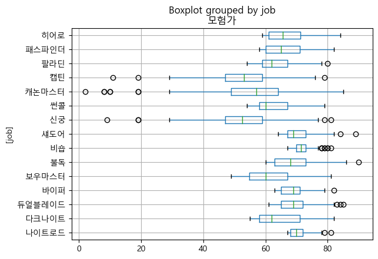

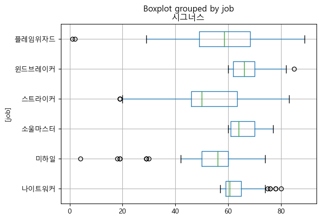

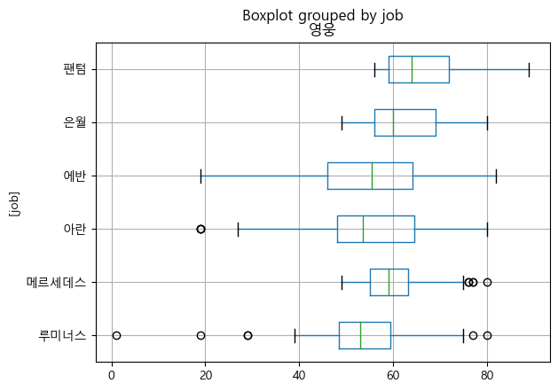

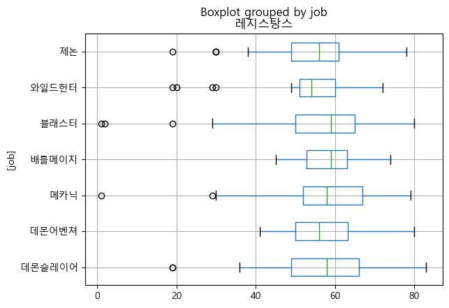

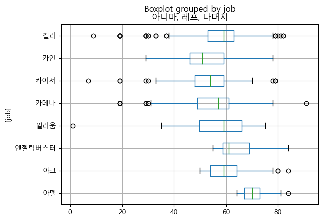

```python
#plt.boxplot(x=all_job[['floor']], by=all_job[['job']])
plt.rcParams['font.family'] ='Malgun Gothic'
plt.rcParams['axes.unicode_minus'] =False


adventurer.iloc[:,0:3:2].boxplot(by='job',vert = 0);
plt.title('모험가')

signus.iloc[:,0:3:2].boxplot(by='job',vert = 0);
plt.title('시그너스')

six_hero.iloc[:,0:3:2].boxplot(by='job',vert = 0);
plt.title('영웅')

resistance.iloc[:,0:3:2].boxplot(by='job',vert = 0);
plt.title('레지스탕스')

another.iloc[:,0:3:2].boxplot(by='job',vert = 0);
plt.title('아니마, 레프, 나머지')

plt.show()
```

`-` 박스플랏 해석

- 박스면적이 좁은 직업은 대체로 층수또한 높은 편임
  - 무릉을 치는 인구가 많아서 상위 랭킹에 드는 컷이 높다라고 해석이 가능
  - 직업의 인기와 상관관계가 있을 것으로 보인다.
- 박스면접이 넓은 직업은 상위 100명의 무릉 층수의 분포가 널리 펴져있다는 것을 의미
  - 상대적으로 고스펙유저가 적고 직업의 인기가 적다는 것을 보여줌 또는 신직업이어서 유입이 적은 경우도 보인다
- 무릉이 좋다는 인식을 가진 직업은 대체로 층수가 좋게 나옴

```python
#all_job.groupby('job').describe()

all_df = pd.concat([adventurer,signus,six_hero,resistance,another])

all_mean = all_df.iloc[:,0:3:2].groupby('job').describe().iloc[:,1].sort_values(ascending = False)
pd.DataFrame(all_mean)
```

| job | floor mean |
| --- | --- |
| 비숍 | 71.870000 |
| 나이트로드 | 70.660000 |
| 아델 | 70.620000 |
| 섀도어 | 70.070000 |
| 듀얼블레이드 | 69.300000 |
| 바이퍼 | 68.670000 |
| 불독 | 68.510000 |
| 히어로 | 66.870000 |
| 윈드브레이커 | 66.850000 |
| 패스파인더 | 66.160000 |
| 팬텀 | 66.130000 |
| 소울마스터 | 65.000000 |
| 다크나이트 | 64.740000 |
| 엔젤릭버스터 | 63.520000 |
| 팔라딘 | 63.030000 |
| 나이트워커 | 62.830000 |
| 썬콜 | 62.390000 |
| 은월 | 61.670000 |
| 보우마스터 | 60.950000 |
| 아크 | 60.610000 |
| 메르세데스 | 59.980000 |
| 배틀메이지 | 58.500000 |
| 칼리 | 57.814318 |
| 메카닉 | 57.484375 |
| 데몬어벤져 | 57.240000 |
| 일리움 | 56.909091 |
| 블래스터 | 56.442857 |
| 데몬슬레이어 | 56.365079 |
| 플레임위자드 | 56.038462 |
| 제논 | 54.955882 |
| 아란 | 54.760000 |
| 캐논마스터 | 53.985507 |
| 미하일 | 53.696629 |
| 루미너스 | 53.480000 |
| 카데나 | 53.314607 |
| 에반 | 53.021739 |
| 카이저 | 52.989796 |
| 캡틴 | 52.647887 |
| 와일드헌터 | 52.560000 |
| 신궁 | 51.943182 |
| 스트라이커 | 51.769231 |
| 카인 | 51.640000 |

`-` 무릉 층수 평균 내림차순

- 검은마법사 격수 스펙 60층을 기준으로 직업의 선호도를 상관지을 수 있음
- 대부분의 선호도와 인식이 높은 직업은 평균 60층 이상에 위치하고 있다.

```python
all_75 = all_df.iloc[:,0:3:2].groupby('job').describe().iloc[:,6].sort_values(ascending = False)
all_25 = all_df.iloc[:,0:3:2].groupby('job').describe().iloc[:,4].sort_values(ascending = False)

pd.DataFrame({'box':all_75 - all_25}).sort_values(by='box')
```

| job | box |
| --- | --- |
| 비숍 | 3.00 |
| 나이트로드 | 4.00 |
| 나이트워커 | 6.00 |
| 아델 | 6.00 |
| 섀도어 | 6.00 |
| 바이퍼 | 6.00 |
| 듀얼블레이드 | 7.00 |
| 팔라딘 | 8.00 |
| 윈드브레이커 | 8.00 |
| 메르세데스 | 8.25 |
| 와일드헌터 | 9.00 |
| 소울마스터 | 9.00 |
| 썬콜 | 9.00 |
| 불독 | 10.00 |
| 칼리 | 10.00 |
| 미하일 | 10.00 |
| 아크 | 10.00 |
| 엔젤릭버스터 | 10.25 |
| 히어로 | 10.25 |
| 배틀메이지 | 10.25 |
| 패스파인더 | 11.00 |
| 루미너스 | 11.00 |
| 카이저 | 11.00 |
| 신궁 | 12.00 |
| 캡틴 | 12.00 |
| 카데나 | 12.00 |
| 제논 | 12.00 |
| 보우마스터 | 12.25 |
| 은월 | 13.00 |
| 카인 | 13.00 |
| 다크나이트 | 13.00 |
| 팬텀 | 13.00 |
| 데몬어벤져 | 13.25 |
| 메카닉 | 15.00 |
| 블래스터 | 15.00 |
| 캐논마스터 | 15.00 |
| 일리움 | 16.25 |
| 아란 | 16.50 |
| 데몬슬레이어 | 17.00 |
| 스트라이커 | 17.50 |
| 에반 | 18.25 |
| 플레임위자드 | 19.25 |

`-` 박스플랏의 IQR

- IQR값이 작으면 작을 수록 유저층이 탄탄한 것으로 볼수 있음
  - 상위 25%와 하위 75%의 층수의 격차가 작다는 것은 그만큼 고스펙유저들이 촘촘히 위치하고 있다는 의미로 해석 가능

```python
all_count = all_df.iloc[:,0:3:2].groupby('job').describe().iloc[:,0].sort_values()
pd.DataFrame(all_count).head(16)
```

| job | floor count |
| --- | --- |
| 와일드헌터 | 25.0 |
| 스트라이커 | 39.0 |
| 일리움 | 44.0 |
| 플레임위자드 | 52.0 |
| 데몬슬레이어 | 63.0 |
| 메카닉 | 64.0 |
| 제논 | 68.0 |
| 캐논마스터 | 69.0 |
| 블래스터 | 70.0 |
| 캡틴 | 71.0 |
| 루미너스 | 75.0 |
| 신궁 | 88.0 |
| 미하일 | 89.0 |
| 카데나 | 89.0 |
| 에반 | 92.0 |
| 카이저 | 98.0 |

- api에서 100개 이상의 카운트를 가지고 오지 못한 16개의 직업이다
  - 다른 직업에 비해 인기가 없는 직업이라고 파악이 되어짐

```python
all_10= all_df.iloc[:,0:3:2].groupby('job').head(5).groupby('job').describe().iloc[:,1].sort_values(ascending = False)

pd.DataFrame(all_10)
```

| job | floor mean |
| --- | --- |
| 팬텀 | 84.6 |
| 불독 | 83.6 |
| 듀얼블레이드 | 83.0 |
| 섀도어 | 82.0 |
| 다크나이트 | 81.2 |
| 아델 | 80.8 |
| 히어로 | 80.4 |
| 윈드브레이커 | 80.0 |
| 비숍 | 79.8 |
| 아크 | 79.8 |
| 엔젤릭버스터 | 79.4 |
| 아란 | 79.2 |
| 보우마스터 | 79.2 |
| 패스파인더 | 79.0 |
| 카데나 | 79.0 |
| 나이트로드 | 78.8 |
| 플레임위자드 | 78.6 |
| 데몬어벤져 | 78.6 |
| 캐논마스터 | 78.4 |
| 에반 | 78.2 |
| 바이퍼 | 78.0 |
| 팔라딘 | 77.8 |
| 나이트워커 | 77.6 |
| 은월 | 77.4 |
| 메르세데스 | 77.2 |
| 카이저 | 77.0 |
| 블래스터 | 76.8 |
| 썬콜 | 76.8 |
| 신궁 | 76.6 |
| 데몬슬레이어 | 75.8 |
| 루미너스 | 75.6 |
| 소울마스터 | 75.0 |
| 제논 | 74.2 |
| 메카닉 | 74.2 |
| 스트라이커 | 74.2 |
| 일리움 | 73.8 |
| 캡틴 | 72.6 |
| 배틀메이지 | 72.4 |
| 카인 | 71.6 |
| 미하일 | 71.0 |
| 칼리 | 70.2 |
| 와일드헌터 | 68.8 |

[output not shown]